# Bike Sharing Analysis with Ford GoBike Data

# by Norah Alotaibi

## Introduction

> This project has two parts that demonstrate the importance and value of data visualization techniques in the data analysis process. In the first part, I will use Python visualization libraries to systematically explore a selected dataset, starting from plots of single variables and building up to plots of multiple variables. In the second part, you will produce a short presentation that illustrates interesting properties, trends, and relationships that I discovered in my selected dataset. The primary method of conveying my findings will be through transforming your exploratory visualizations from the first part into polished, explanatory visualizations.

```python
# import all packages needs
import numpy as np
import pandas as pd
import matplotlib.pyplot as plt
import seaborn as sns
import datetime

import glob
import os

%matplotlib inline
```

```python
# read dataset
df = pd.read_csv('2017-fordgobike-tripdata.csv')
```

## Exploration Data

### Research Question 1 what are the age range more use Ford GoBike ?

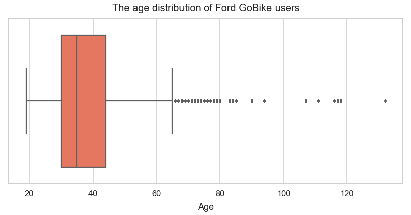

```python
plt.figure(figsize=(14,6))
sns.boxplot(x='member_age', data=df, palette='Reds', orient='h')
plt.title("The age distribution of Ford GoBike users", fontsize=20, y=1.03)
plt.xlabel("Age", fontsize=18, labelpad=10)
plt.savefig('The age distribution of Ford GoBike users.png');
```

### Result 1 in the chart shows the age of Ford GoBike users are between 30 to 44.

### Research Question 2 When are most trips taken in terms of month of the year?

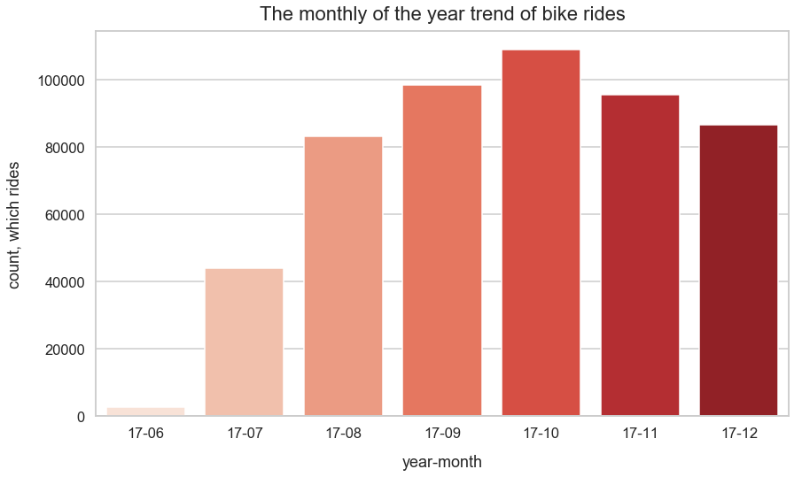

```python
plt.figure(figsize=(14,8))
sns.countplot(x='start_time_year_month_renamed', palette="Reds", data=df.sort_values(by='start_time_year_month_renamed'))
plt.title('The monthly of the year trend of bike rides', fontsize=22, y=1.015)
plt.xlabel('year-month', labelpad=16)
plt.ylabel('count, which rides', labelpad=16)
ax = plt.gca()
plt.savefig('The monthly of the year trend of bike rides.png')
```

### Ford GoBike rides per hours of the day

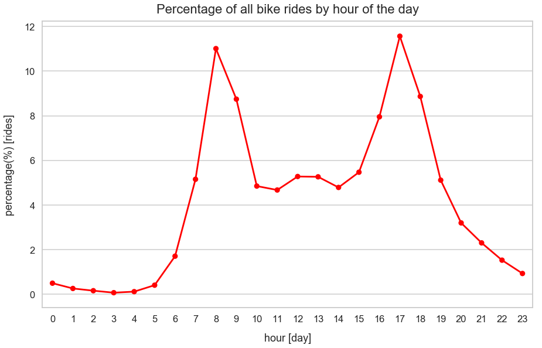

```python
plt.figure(figsize=(15,9))
sns.pointplot(x='start_time_hour', y='bike_id', scale=.7, color='red', data=hour_df)
plt.title('Percentage of all bike rides by hour of the day', fontsize=22, y=1.015)
plt.xlabel('hour [day]', labelpad=16)
plt.ylabel('percentage(%) [rides]', labelpad=16)
plt.savefig('Percentage of all bike rides by hour of the day.png');
```

### Research Question 3 what are the age range for bike rides in the months ?

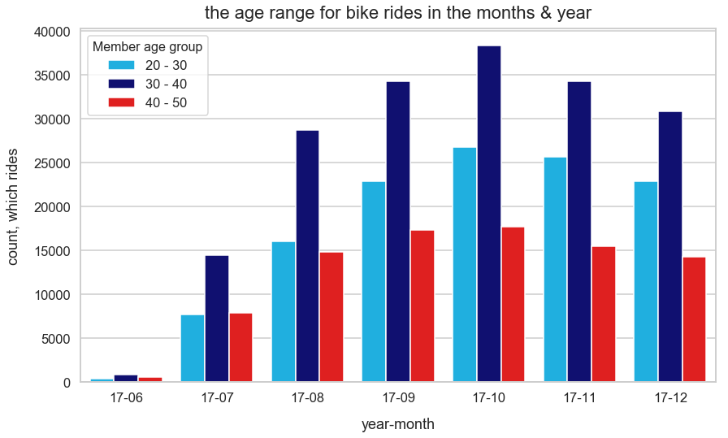

```python
plt.figure(figsize=(14,8))
my_palette = {'20 - 30': 'deepskyblue', '30 - 40': 'navy', '40 - 50': 'red'}
ax = sns.countplot(x='start_time_year_month_renamed', hue='member_age_bins', palette=my_palette, data=df[df['member_age_bins'].isin(['20 - 30', '30 - 40', '40 - 50'])].sort_values(by=['start_time_year_month_renamed', 'member_age_bins']))
plt.title('the age range for bike rides in the months & year', fontsize=22, y=1.015)
plt.xlabel('year-month', labelpad=16)
plt.ylabel('count, which rides', labelpad=16)
leg = ax.legend()
leg.set_title('Member age group',prop={'size':16})
ax = plt.gca()
plt.savefig('the age range for bike rides in the months & year.png');
```

### Result 3 in the chart illustrates that age range from 30 to 40 more use Ford GoBike, whereas the 40 to 50 age less use of Ford GoBike. all the ages are use Ford GoBike in october more than others months

### Research Question 4 what are the percentage of all bike rides per gender?

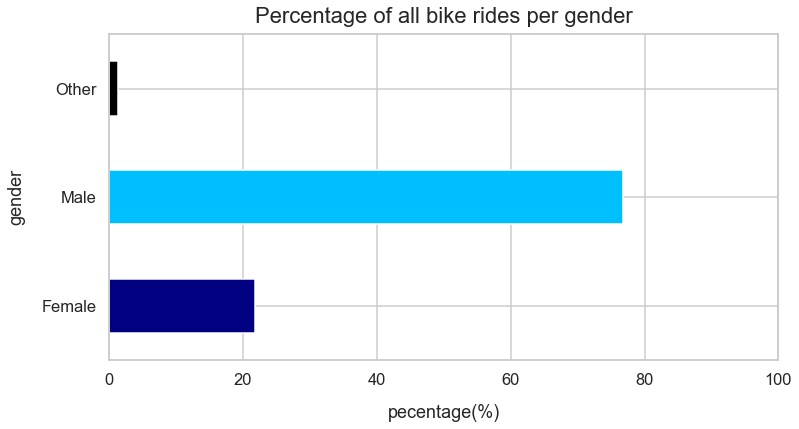

```python
new_color = ['navy', 'deepskyblue', 'black']
gender_df['perc'].plot(kind='barh', color=new_color, figsize=(12,6))
plt.title('Percentage of all bike rides per gender', fontsize=22, y=1.015)
plt.ylabel('gender', labelpad=16)
plt.xlabel('pecentage(%)', labelpad=16)
plt.xticks(rotation=360)
plt.xlim(0,100)
plt.savefig('Percentage of all bike rides per gender.png');
```

### Research Question 5 Does the above depend on if a user is a subscriber or customer?

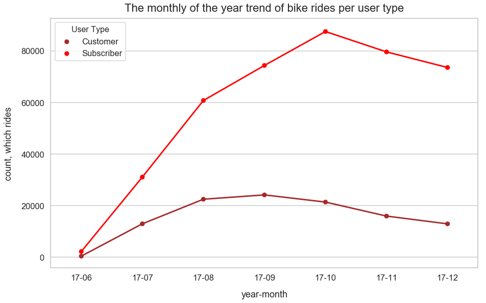

```python
plt.figure(figsize=(15,9))
my_palette = {'Subscriber':'red', 'Customer':'brown'}
ax = sns.pointplot(x='start_time_year_month_renamed', y=0, hue='user_type', palette=my_palette, scale=.7, data=user_type_df)
plt.title('The monthly of the year trend of bike rides per user type', fontsize=22, y=1.015)
plt.xlabel('year-month', labelpad=16)
plt.ylabel('count, which rides', labelpad=16)
leg = ax.legend()
leg.set_title('User Type',prop={'size':16})
ax = plt.gca()
plt.savefig('The monthly of the year trend of bike rides per user type.png');
```

### Result 5 the subscriber users use Ford GoBike more than customer during the year. And, the subscriber users use Ford GoBike more in october.

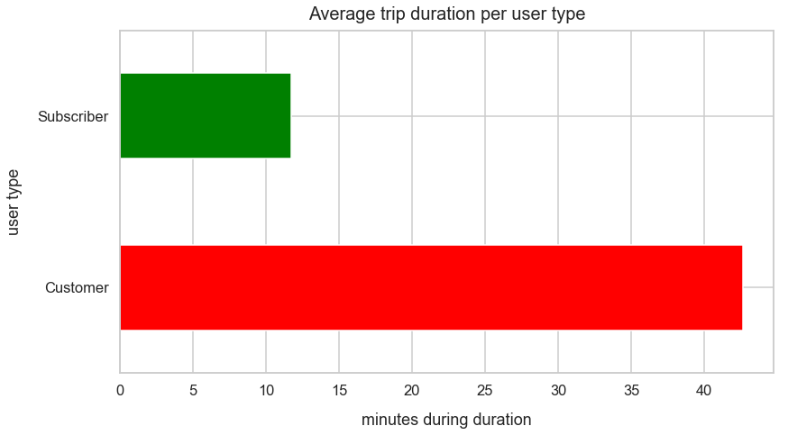

```python
new_color=['red', 'green']
ax = df.groupby('user_type')['duration_min'].mean().plot(kind='barh', color=new_color, figsize=(13,7))
ax.set_title('Average trip duration per user type', fontsize=20, y=1.015)
ax.set_ylabel('user type', labelpad=16)
ax.set_xlabel('minutes during duration', labelpad=16)
plt.savefig('Average trip duration per user type.png');
```

# Univariate Exploration

### In this part, individuals variables will be explored.

### Average Bike Trip Duration (Seconds)

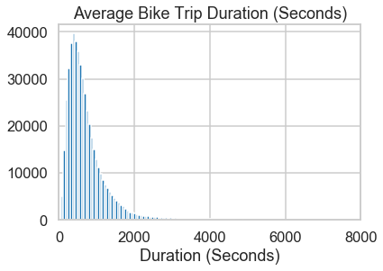

```python
#Plotting of the average trip duration as a main variable.
bin_edges = np.arange(0, df['duration_sec'].max() + 100 , 60)
plt.hist(data = df , x = 'duration_sec' , bins = bin_edges)
plt.xlim(0,8000)
plt.title('Average Bike Trip Duration (Seconds)')
plt.xlabel('Duration (Seconds)');
plt.savefig('Average Bike Trip Duration (Seconds).png');
```

### Average Bike Trip Duration (Minutes)

[output not shown]

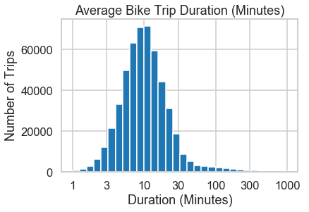

```python
#Log transform to better help understand the data
bins = 10**np.arange(0 , 3 + 0.1 , 0.1)
ticks =  [ 1 , 3, 10, 30, 100, 300, 1000]
labels = ['{}'.format(v) for v in ticks]
plt.hist(data = df , x = 'duration_min' , bins = bins);
plt.xscale('log');
plt.xticks(ticks,labels);
plt.xlabel('Duration (Minutes)');
plt.title('Average Bike Trip Duration (Minutes)');
plt.ylabel('Number of Trips');
plt.savefig('Average Bike Trip Duration (Minutes)'.png);
```

# Bivariate Exploration

### In this section, the investigate of the relationship between average bike ride time (minutes) and months of the year.

### Monthly Trip Duration (minutes)

[output not shown]

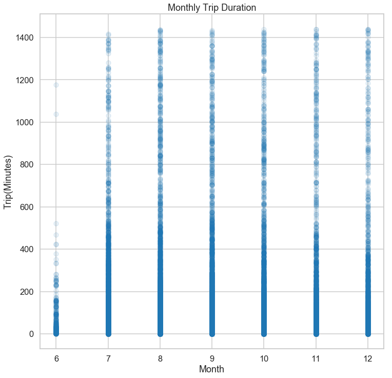

```python
# Checking bike ride duration for each month
plt.figure(figsize = [12,12])
plt.scatter(data = df , x = 'month' , y = 'duration_min' , alpha = 0.1 )
plt.title('Monthly Trip Duration')
plt.xlabel('Month')
plt.ylabel('Trip(Minutes)');
plt.savefig('Monthly Trip Duration'.png);
```

# Multivariate Exploration

### In this section , the relationship between month, trip length and gender.

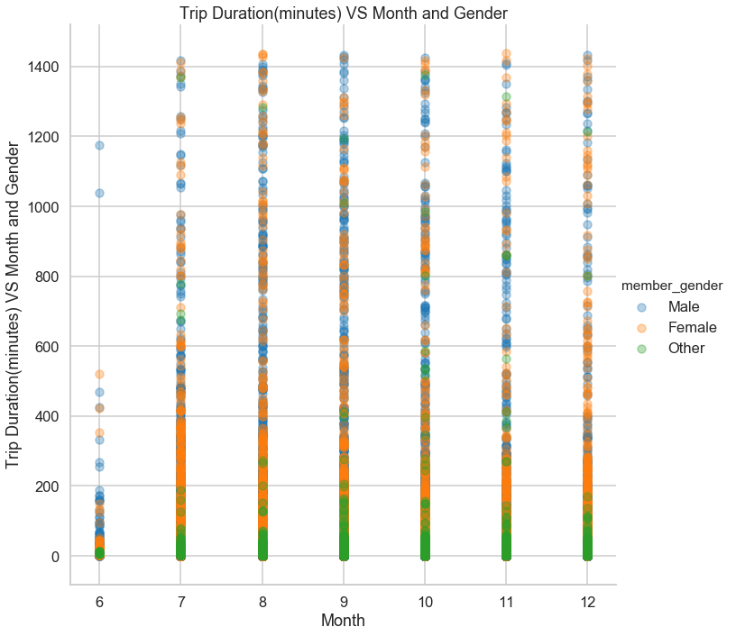

```python
# Finding out how the average trip time is affected by gender and month.
g = sns.FacetGrid(data =  df, hue = 'member_gender', height = 10)
g.map(plt.scatter, 'month','duration_min', alpha = 1/3)
g.add_legend()
plt.title('Trip Duration(minutes) VS Month and Gender')
plt.xlabel('Month')
plt.ylabel('Trip Duration(minutes) VS Month and Gender');
```